# Blog 2

Shaya Engelman

2024-05-07

Title: Balancing Act: Tackling Imbalanced Target Variables in Logistic Regression with R

In the realm of predictive modeling, logistic regression serves as a powerful tool for analyzing the relationship between independent variables and a binary outcome. However, when faced with imbalanced target variables, where one class is significantly underrepresented compared to the other, traditional logistic regression can falter. In this blog post, we’ll explore how to identify and effectively deal with imbalanced target variables using R.

### Generating Dummy Data

Before diving into modeling, let’s generate some dummy data to illustrate the concepts discussed:

```r
# Generating dummy data
set.seed(123)
n <- 1000  # Total number of samples
p <- 0.8   # Probability of belonging to majority class
data <- data.frame(
  target = factor(ifelse(runif(n) < p, "Majority", "Minority")),
  feature1 = rnorm(n),
  feature2 = rnorm(n)
)
```

In this example, we create a dataset with 1000 samples, where the target variable has two classes: “Majority” and “Minority”. We’ll use these dummy data throughout the blog post to demonstrate various techniques for handling class imbalance.

### Identifying Imbalanced Target Variables

Before diving into modeling, it’s crucial to understand the distribution of the target variable:

```r
library(ggplot2)
# Checking class distribution
class_distribution <- table(data$target)
print(class_distribution)
```

```
##
## Majority Minority
##      802      198
```

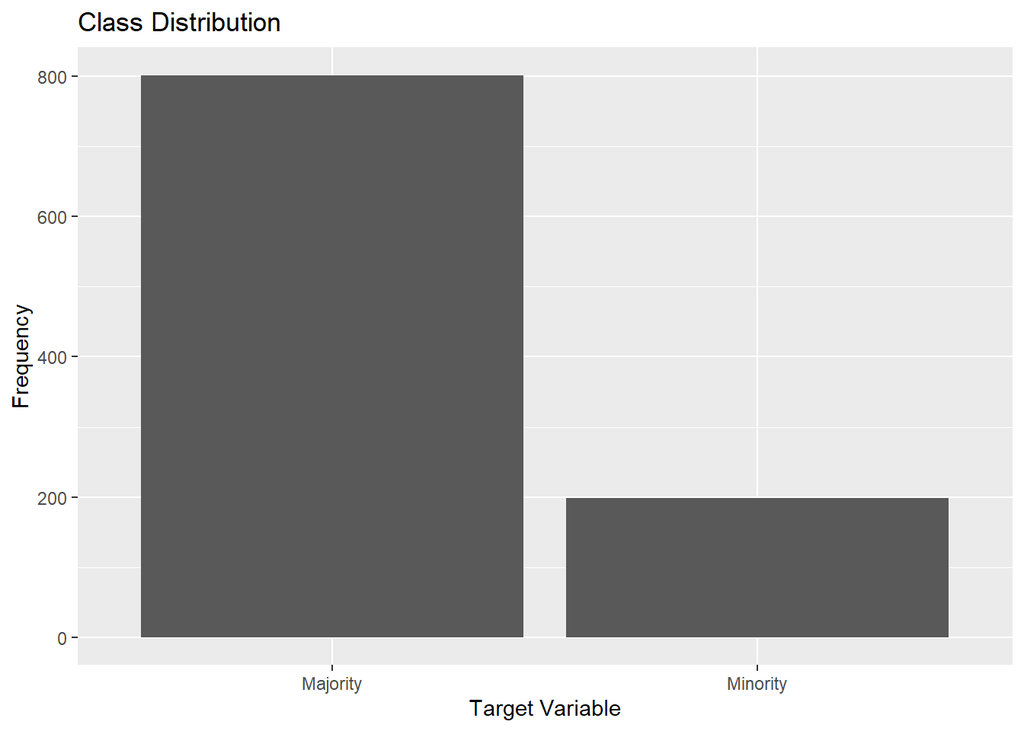

```r
# Visualizing class distribution
ggplot(data, aes(x = target)) +
  geom_bar() +
  labs(title = "Class Distribution",
       x = "Target Variable",
       y = "Frequency")
```

These code snippets provide insights into the imbalance between classes, allowing us to visualize and quantify the distribution.

### Training Logistic Regression Model

We split the data into training and testing sets and train a logistic regression model:

```r
library(caret)
# Splitting data into training and testing sets
set.seed(123) # for reproducibility
train_index <- createDataPartition(data$target, p = 0.8, list = FALSE)
train_data <- data[train_index, ]
test_data <- data[-train_index, ]

# Training logistic regression model
log_model <- train(target ~ ., data = train_data, method = "glm", trControl = trainControl(method = "cv", number = 5, verboseIter = TRUE))
```

### Dealing with Imbalanced Target Variables

#### Oversampling Minority Class

To address imbalance, we can oversample the minority class using the ROSE package:

```r
library(ROSE)
# Oversampling minority class
# Get the number of instances in the majority class
n_majority = max(table(train_data$target))

# Set N to be twice the number of instances in the majority class
N = 2 * n_majority

oversampled_data <- ovun.sample(target ~ ., data = train_data, method = "over", N = N)$data


# Training logistic regression model on oversampled data
log_model_oversampled <- train(target ~ ., data = oversampled_data, method = "glm", trControl = trainControl(method = "cv", number = 5, verboseIter = TRUE))
```

### Evaluating Model Performance

Finally, we evaluate the performance of both models:

```r
# Making predictions on test data
predictions <- predict(log_model, newdata = test_data)

# Evaluating model performance
conf_matrix <- confusionMatrix(predictions, test_data$target)
print(conf_matrix)
```

```
## Confusion Matrix and Statistics
##
##           Reference
## Prediction Majority Minority
##   Majority      160       39
##   Minority        0        0
##
##                Accuracy : 0.804
##                  95% CI : (0.742, 0.8568)
##     No Information Rate : 0.804
##     P-Value [Acc > NIR] : 0.5427
##
##                   Kappa : 0
##
##  Mcnemar's Test P-Value : 1.166e-09
##
##             Sensitivity : 1.000
##             Specificity : 0.000
##          Pos Pred Value : 0.804
##          Neg Pred Value :   NaN
##              Prevalence : 0.804
##          Detection Rate : 0.804
##    Detection Prevalence : 1.000
##       Balanced Accuracy : 0.500
##
##        'Positive' Class : Majority
##
```

```r
# Making predictions on test data with oversampled model
predictions_oversampled <- predict(log_model_oversampled, newdata = test_data)

# Evaluating oversampled model performance
conf_matrix_oversampled <- confusionMatrix(predictions_oversampled, test_data$target)
print(conf_matrix_oversampled)
```

```
## Confusion Matrix and Statistics
##
##           Reference
## Prediction Majority Minority
##   Majority       91       18
##   Minority       69       21
##
##                Accuracy : 0.5628
##                  95% CI : (0.4909, 0.6328)
##     No Information Rate : 0.804
##     P-Value [Acc > NIR] : 1
##
##                   Kappa : 0.0717
##
##  Mcnemar's Test P-Value : 8.296e-08
##
##             Sensitivity : 0.5687
##             Specificity : 0.5385
##          Pos Pred Value : 0.8349
##          Neg Pred Value : 0.2333
##              Prevalence : 0.8040
##          Detection Rate : 0.4573
##    Detection Prevalence : 0.5477
##       Balanced Accuracy : 0.5536
##
##        'Positive' Class : Majority
##
```

### Exploring Alternative Approaches

While oversampling is a widely used technique for handling imbalanced datasets, it’s not the only option available. Another method worth considering is the use of algorithmic approaches that inherently handle class imbalance. One such approach is the implementation of ensemble methods, particularly those like Random Forest and Gradient Boosting. Thse methods are beyond the scope of this blog post right now.

### Conclusion

While oversampling remains a popular choice, it’s essential to consider the potential risks, such as overfitting and introduction of noise, especially when dealing with large imbalances. Exploring alternative approaches like ensemble methods can provide a valuable addition to our toolkit, offering robust solutions that enhance model performance and generalization.

As we continue to navigate the complexities of predictive modeling, understanding the nuances of class imbalance and employing appropriate strategies will be crucial for building accurate and reliable models in real-world scenarios.